# First attempt at second spatial field

Emma Skarstein

4/15/2020

```r
library(ggplot2)
library(sf) # for sf objects
library(plyr)
library(dplyr) # for smoother dataframe-manipulation
library(here) # for cleaner filepath-handling
library(ggmap) # also for nice maps
library(maps)
library(RColorBrewer)
library(PointedSDMs)
library(sp)
library(spatstat)
library(maptools)
library(INLA)
library(reshape2)
library(rgeos)
library(fields)
library(viridis)
library(ggpubr)
```

## Loading Norway map

```r
# MAP ---------------------------------------------------------------------------------------------------------
norway <- ggplot2::map_data("world", region = "Norway(?!:Svalbard)")
norway <- setdiff(norway, filter(norway, subregion == "Jan Mayen"))
Projection <- CRS("+proj=longlat +ellps=WGS84")
norwayfill <- map("world", "norway", fill=TRUE, plot=FALSE,
                  ylim=c(58,72), xlim=c(4,32))
IDs <- sapply(strsplit(norwayfill$names, ":"), function(x) x[1])
norway.poly <- map2SpatialPolygons(norwayfill, IDs = IDs,
                                   proj4string = Projection)
```

## Setting up observation and environmental data

Next we load the observations as well as the environmental data.

```r
# LOADING DATA AND COVARIATES ---------------------------------------------------------------------------------

# Covariates
covariateData <- readRDS("../data/environmental_covariates.RDS")
covariateData <- covariateData[complete.cases(covariateData$decimalLatitude,covariateData$decimalLongitude,covariateData$area_km2,covariateData$HFP),]
covariateData <- covariateData %>% mutate(log_area = log(area_km2)) %>% select(-c(ebint, no_vatn_lnr, eb_waterregionID))

head(covariateData)
```

```
##   waterBodyID decimalLatitude decimalLongitude   area_km2 perimeter_m
## 1     3531617        64.30199        11.049305 0.15370997        3492
## 2     3531112        63.73470        10.680250 0.13366573        2349
## 3     2877565        59.04880         7.863702 0.11454878        1632
## 4     3355832        60.23034         6.427800 0.01008058         486
## 5     2695076        59.58998        11.470182 0.01569860         642
## 6     3311288        58.08718         7.331050 0.01509316         835
##   distance_to_road eurolst_bio10 catchment_area_km2      SCI       HFP
## 1             5681     127.89760             0.7603 1.144443  1.439096
## 2             1501     121.96890             0.9819 1.534130  4.071300
## 3             3602     124.03020             1.9025 1.774869  5.000000
## 4              156      95.41962             0.4089 1.416126  2.775584
## 5              905     135.03910             7.5086 1.554206 11.527012
## 6              701     141.01520             0.4762 1.573568 12.144801
##    log_area
## 1 -1.872688
## 2 -2.012413
## 3 -2.166755
## 4 -4.597145
## 5 -4.154184
## 6 -4.193514
```

```r
# Choose from
# "decimalLatitude", "decimalLongitude",
# "area_km2", "perimeter_m", "distance_to_road",
# "eurolst_bio10", "catchment_area_km2", "SCI", "HFP"
Use <- c("decimalLongitude","decimalLatitude", "log_area", "perimeter_m",
         "eurolst_bio10", "SCI")

Covariates <- SpatialPointsDataFrame(coords = covariateData[,c("decimalLongitude","decimalLatitude")],
                                     data = covariateData[,Use],
                                     proj4string = Projection)
Covariates@data <- data.frame(apply(Covariates@data, 2, scale))  # scale the covariates

# Observations
Data_survey_df <- readRDS("../Fish_status_survey_of_nordic_lakes/data/clean.rds")
Data_survey <- SpatialPointsDataFrame(coords = Data_survey_df[,c("decimalLongitude","decimalLatitude")],
                                      data = Data_survey_df[,c("occurrenceStatus","species")],
                                      proj4string = Projection)

Data_artsobs_df <- readRDS("../Nordic_Species_Observation_Services/data/clean.rds")
Data_artsobs <- SpatialPointsDataFrame(coords = Data_artsobs_df[,c("decimalLongitude","decimalLatitude")],
                                       data = Data_artsobs_df[,c("occurrenceStatus","species")],
                                       proj4string = Projection)
```

Now we have the covariates in ‘Covariates’, as well as two types of data sets in ‘Data_survey’ and ‘Data_artsobs’.

## Stacks!

### Integration stack

The integration stack gives the points in the INLA mesh. We first create this mesh from the Norway-polygon-object:

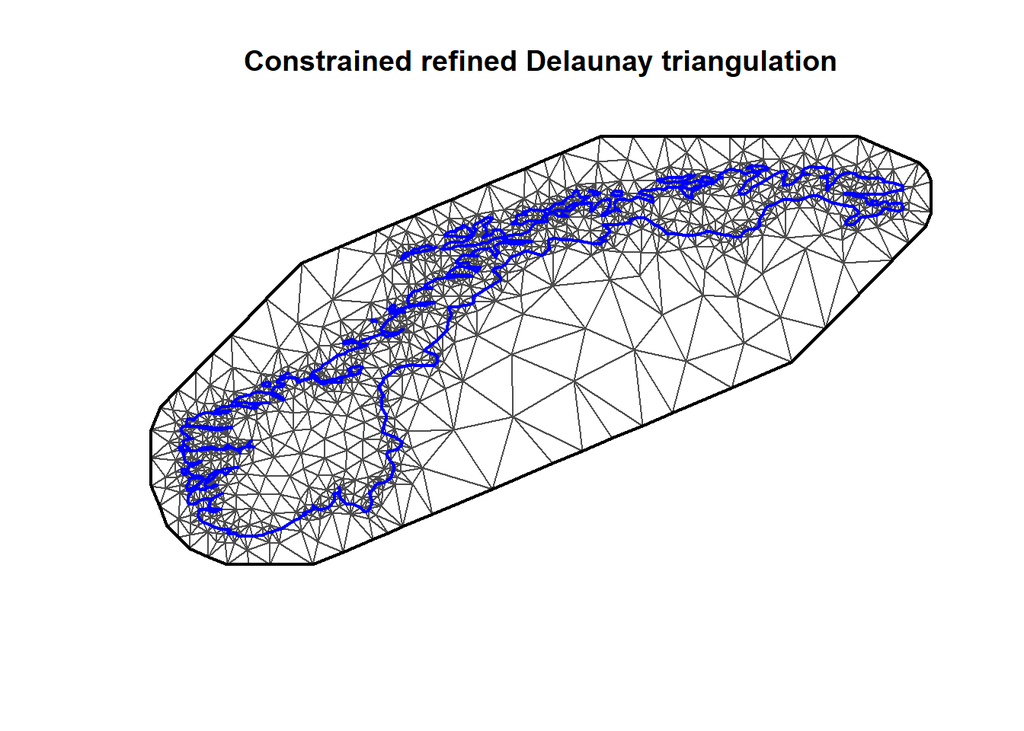

```r
# INTEGRATION STACK --------------------------------------------------------------------------------------------
Meshpars <- list(cutoff=0.08, max.edge=c(1, 3), offset=c(1,1))
Mesh <- MakeSpatialRegion(data=NULL, bdry=norway.poly, meshpars=Meshpars,
                          proj = Projection)
plot(Mesh$mesh)
```

And then we can create the actual integration stack:

```r
stk.ip <- MakeIntegrationStack(mesh=Mesh$mesh, data=Covariates,
                               area=Mesh$w, tag='ip', InclCoords=TRUE)
```

### Stack for survey data (structured)

The stack for the structured survey data is made the same way as before, nothing changes here. This corresponds to the predictor

$$\alpha_{PA} + \hat\beta_{x}(s) + \hat\xi(s),$$
where $\alpha_{PA}$ is the intercept, $\hat\beta_{x}(s)$ is the estimated environmental field and $\hat\xi(s)$ is the estimated spatial field.

```r
# SURVEY, STRUCTURED STACK ---------------------------------------------------------------------------------------------
stk.survey <- MakeBinomStack(observs = Data_survey, data = Covariates,
                             mesh=Mesh$mesh, presname="occurrenceStatus",
                             tag="survey", InclCoords=TRUE)
# Note that when using 'MakeBinomStack' here, the spatial effect in stk.survey is just called "i",
#  while in the unstructured data stack we called the corresponding effect 'unstr_field'.
```

### Stack for citizen science data (unstructured)

When we get to the unstructured citizen science data, this is where things start to change. Since we want to add a second spatial field here, we can no longer use the function ‘MakePointsStack()’ from the ‘PointedSDM’ package. This now corresponds to the predictor
$$\alpha_{PO} + \hat\beta_{x}(s) + \hat\xi(s) + \hat\zeta(s).$$
Note that we now have a different intercept, but the environmental and first spatial field are the same as for the structured data. Then at last we have the second estimated spatial field, $\hat\zeta(s)$.

```r
# ARTSOBS, UNSTRUCTURED STACK -------------------------------------------------------------------------------------------
# Finding the covariates that are closest to the observation points
NearestCovs_unstr <- GetNearestCovariate(points = Data_artsobs, covs = Covariates)
NearestCovs_unstr@data[ , "int.artsobs"] <- 1 # add intercept

# Projector matrix from mesh to unstructured data
projmat.artsobs <- inla.spde.make.A(mesh = Mesh$mesh, loc = as.matrix(Data_artsobs@coords))

stk.artsobs <- inla.stack(data = list(resp = cbind(rep(1,nrow(NearestCovs_unstr)), NA),
                                              e = rep(0, nrow(NearestCovs_unstr))),
                                    A = list(1, projmat.artsobs),
                                    tag = "artsobs",
                                    effects = list(NearestCovs_unstr@data,
                                                 list(unstr_field = 1:Mesh$mesh$n,
                                                      bias_field = 1:Mesh$mesh$n))) # This is for the second spatial field!
```

### Prediction stack

In order to do predictions we make a prediction stack, just the same as before.

```r
# PREDICTIONS ----------------------------------------------------------------------------------------------------------
Nxy.scale <- 0.1 # use this to change the resolution of the predictions
Nxy <- round(c(diff(norway.poly@bbox[1,]), diff(norway.poly@bbox[2,]))/Nxy.scale)
stk.pred <- MakeProjectionGrid(nxy=Nxy, mesh=Mesh$mesh, data=Covariates,
                               tag='pred',boundary=norway.poly)
```

## Fitting the model

Then finally we get to the model fitting. Here we need to change the formula to include the second spatial field.

```r
# CONSTRUCTING FORMULA -------------------------------------------------------------------------------------------------

# First specifying the formula components
intercepts <- "int.survey + int.artsobs - 1"
env_effects <- paste(Use, collapse = ' + ')
spatial_effects <- "f(unstr_field, model = Mesh$spde) +
                    f(i, copy = 'unstr_field', fixed = TRUE) +
                    f(bias_field, model = Mesh$spde)"

formulaJ <- as.formula(paste(c("resp ~ 0 ", intercepts, env_effects, spatial_effects), collapse = " + "))
```

The formula is then:

```r
formulaJ
```

```
## resp ~ 0 + int.survey + int.artsobs - 1 + decimalLongitude +
##     decimalLatitude + log_area + perimeter_m + eurolst_bio10 +
##     SCI + f(unstr_field, model = Mesh$spde) + f(i, copy = "unstr_field",
##     fixed = TRUE) + f(bias_field, model = Mesh$spde)
```

We then fit the model in the same way as before:

```r
# FITTING MODEL -------------------------------------------------------------------------
NorwegianModel <- FitModel(stk.survey, stk.artsobs,
                           stk.ip, stk.pred$stk,
                           formula = formulaJ,
                           mesh = Mesh$mesh,
                           predictions = TRUE,
                           spat.ind = NULL) # About this: I've included the spatial fields
                                            # in the formula, so this should be fine,
                                            # but it may be possible to remove this and remove
                                            # two of the fields in the formula?
```

Looking at the results:

```r
summary(NorwegianModel$model)
```

```
##
## Call:
##    c("inla(formula = Formula, family = c(\"poisson\", \"binomial\"), data
##    = inla.stack.data(stck), ", " E = inla.stack.data(stck)$e, Ntrials =
##    inla.stack.data(stck)$Ntrials, ", " verbose = FALSE, control.compute =
##    list(waic = waic, dic = dic), ", " control.predictor = list(A =
##    inla.stack.A(stck), link = NULL, ", " compute = TRUE), control.family =
##    list(list(link = \"log\"), ", " list(link = \"cloglog\")),
##    control.results = list(return.marginals.random = FALSE, ", "
##    return.marginals.predictor = FALSE), control.fixed = control.fixed)" )
## Time used:
##     Pre = 12.3, Running = 3252, Post = 1.94, Total = 3266
## Fixed effects:
##                    mean    sd 0.025quant 0.5quant 0.975quant   mode kld
## int.survey       -0.398 0.014     -0.426   -0.398     -0.369 -0.398   0
## int.artsobs       0.694 0.035      0.626    0.694      0.762  0.694   0
## decimalLongitude -0.002 0.004     -0.009   -0.002      0.005 -0.002   0
## decimalLatitude   0.001 0.001     -0.001    0.001      0.003  0.001   0
## log_area          0.011 0.006     -0.002    0.011      0.024  0.011   0
## perimeter_m       0.003 0.002     -0.001    0.003      0.007  0.003   0
## eurolst_bio10     0.031 0.008      0.014    0.031      0.047  0.031   0
## SCI              -0.002 0.007     -0.017   -0.002      0.013 -0.002   0
##
## Random effects:
##   Name     Model
##     unstr_field SPDE2 model
##    bias_field SPDE2 model
##    i Copy
##
## Model hyperparameters:
##                          mean    sd 0.025quant 0.5quant 0.975quant   mode
## Theta1 for unstr_field  2.437 0.243      1.962    2.435      2.920  2.430
## Theta2 for unstr_field -1.459 0.287     -2.039   -1.452     -0.909 -1.429
## Theta1 for bias_field   0.172 0.168     -0.152    0.169      0.507  0.159
## Theta2 for bias_field  -1.348 0.233     -1.827   -1.338     -0.915 -1.303
##
## Expected number of effective parameters(stdev): 52.11(4.85)
## Number of equivalent replicates : 275.79
##
## Marginal log-Likelihood:  -4772.13
## Posterior marginals for the linear predictor and
##  the fitted values are computed
```

We can plot the bias field ($\hat\zeta(s)$) and the shared spatial field ( $\hat\xi(s)$) as follows:

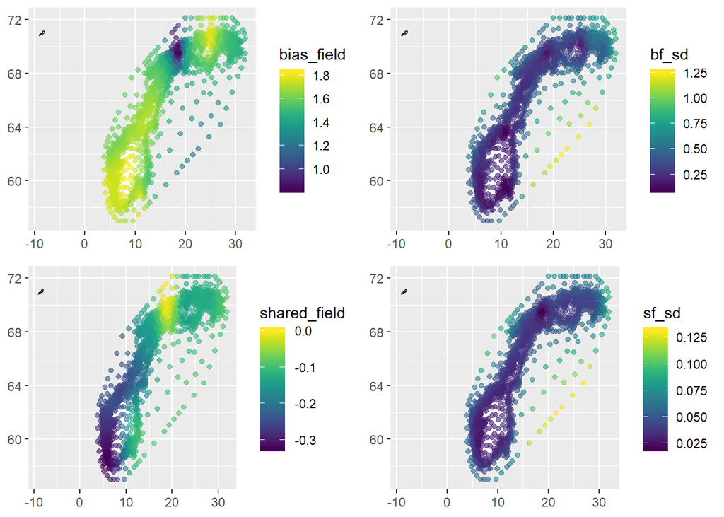

```r
random_sp_effects <- data.frame(cbind(NorwegianModel$model$summary.random$bias_field$mean,
                             NorwegianModel$model$summary.random$bias_field$sd,
                             NorwegianModel$model$summary.random$unstr_field$mean,
                             NorwegianModel$model$summary.random$unstr_field$sd,
                             Mesh$mesh$loc[,1:2]))
colnames(random_sp_effects) <- c("bias_field", "bf_sd", "shared_field", "sf_sd", "longitude", "latitude")

p <- ggplot(random_sp_effects) +
  geom_map(data = norway, map = norway, aes(long, lat, map_id=region),
           color="#2b2b2b", fill = "white") +
  theme(axis.title.x = element_blank(),
        axis.title.y = element_blank())

library(ggpubr)
p1 <- p + geom_point(aes(x = longitude, y = latitude, color = bias_field), alpha = 0.6) +
  scale_color_viridis()
p1.1 <- p + geom_point(aes(x = longitude, y = latitude, color = bf_sd), alpha = 0.6) +
  scale_color_viridis()
p2 <- p + geom_point(aes(x = longitude, y = latitude, color = shared_field), alpha = 0.6) +
  scale_color_viridis()
p2.1 <- p + geom_point(aes(x = longitude, y = latitude, color = sf_sd), alpha = 0.6) +
  scale_color_viridis()

figure1 <- ggarrange(p1, p1.1, p2, p2.1, ncol = 2, nrow = 2)

figure1
```

We can plot the predictions:

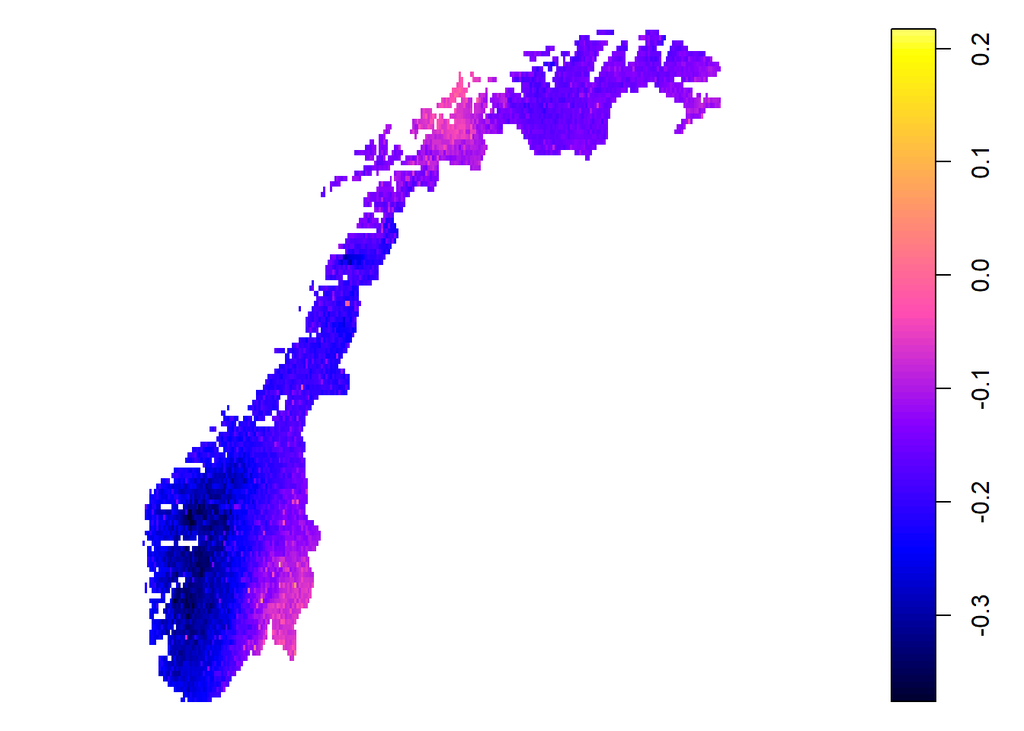

```r
Pred <- SpatialPixelsDataFrame(points=stk.pred$predcoords,
                               data=NorwegianModel$predictions,
                               proj4string=Projection)
Pred@data$precision <- Pred@data$stddev^-2

plot(Pred)
```

```r
plot.mean.stddev <- function(pred){
  ncolors <- 200
  greencols.fn <- colorRampPalette(brewer.pal(9, "Greens"))
  greencols <- greencols.fn(ncolors)
  bluecols.fn <- colorRampPalette(brewer.pal(9, "Blues"))
  bluecols <- bluecols.fn(ncolors)
  map.mean <- mapview::mapview(pred, zcol = c("mean"), legend = TRUE,
                               col.regions = greencols)
  map.stddev <- mapview::mapview(pred, zcol = c("stddev"), legend = TRUE, alpha = 0.3,
                                 col.regions = bluecols)
  leafsync::sync(map.mean, map.stddev)
}

plot.mean.stddev(Pred)
```

[interactive chart not shown]